# FinalProjectRS JH

Alejandro Coy

2019-02-12

### Peer-graded Assignment: Course Project 2

## Introduction

Storms and other severe weather events can cause both public health and economic problems for communities and municipalities. Many severe events can result in fatalities, injuries, and property damage, and preventing such outcomes to the extent possible is a key concern.

This project involves exploring the U.S. National Oceanic and Atmospheric Administration’s (NOAA) storm database. This database tracks characteristics of major storms and weather events in the United States, including when and where they occur, as well as estimates of any fatalities, injuries, and property damage.

The two question this project addrest to respones are the following:

1. Across the United States, which types of events are most harmful with respect to population health?
2. Across the United States, which types of events have the greatest economic consequences?

## Data Analysis

The data was subset in two data frames aiming to response each question. These two data frames contains just the columns necesseary for the analysis. The data was fruther filter for rows with numeric values greater than 0, grouped by group by event type and finally sumarized by sum of the varible of interest.

## Importing Data

The package readr is used to read the file and save it in a data frame called “data”. Summary of the data is presented using summary() function.

```r
library(readr)
library(dplyr)
```

```r
library(ggplot2)
library(tidyr)

data <- read_csv("repdata_data_StormData.csv.bz2")
names(data)
```

```
##  [1] "STATE__"    "BGN_DATE"   "BGN_TIME"   "TIME_ZONE"  "COUNTY"
##  [6] "COUNTYNAME" "STATE"      "EVTYPE"     "BGN_RANGE"  "BGN_AZI"
## [11] "BGN_LOCATI" "END_DATE"   "END_TIME"   "COUNTY_END" "COUNTYENDN"
## [16] "END_RANGE"  "END_AZI"    "END_LOCATI" "LENGTH"     "WIDTH"
## [21] "F"          "MAG"        "FATALITIES" "INJURIES"   "PROPDMG"
## [26] "PROPDMGEXP" "CROPDMG"    "CROPDMGEXP" "WFO"        "STATEOFFIC"
## [31] "ZONENAMES"  "LATITUDE"   "LONGITUDE"  "LATITUDE_E" "LONGITUDE_"
## [36] "REMARKS"    "REFNUM"
```

```r
summary(data)
```

```
##     STATE__       BGN_DATE           BGN_TIME          TIME_ZONE
##  Min.   : 1.0   Length:902297      Length:902297      Length:902297
##  1st Qu.:19.0   Class :character   Class :character   Class :character
##  Median :30.0   Mode  :character   Mode  :character   Mode  :character
##  Mean   :31.2
##  3rd Qu.:45.0
##  Max.   :95.0
##
##      COUNTY       COUNTYNAME           STATE              EVTYPE
##  Min.   :  0.0   Length:902297      Length:902297      Length:902297
##  1st Qu.: 31.0   Class :character   Class :character   Class :character
##  Median : 75.0   Mode  :character   Mode  :character   Mode  :character
##  Mean   :100.6
##  3rd Qu.:131.0
##  Max.   :873.0
##
##    BGN_RANGE        BGN_AZI        BGN_LOCATI     END_DATE
##  Min.   :   0.000   Mode:logical   Mode:logical   Mode:logical
##  1st Qu.:   0.000   NA's:902297    TRUE:1         NA's:902297
##  Median :   0.000                  NA's:902296
##  Mean   :   1.484
##  3rd Qu.:   1.000
##  Max.   :3749.000
##
##  END_TIME         COUNTY_END COUNTYENDN       END_RANGE
##  Mode:logical   Min.   :0    Mode:logical   Min.   :  0.0000
##  NA's:902297    1st Qu.:0    NA's:902297    1st Qu.:  0.0000
##                 Median :0                   Median :  0.0000
##                 Mean   :0                   Mean   :  0.9862
##                 3rd Qu.:0                   3rd Qu.:  0.0000
##                 Max.   :0                   Max.   :925.0000
##
##  END_AZI        END_LOCATI         LENGTH              WIDTH
##  Mode:logical   Mode:logical   Min.   :   0.0000   Min.   :   0.000
##  NA's:902297    NA's:902297    1st Qu.:   0.0000   1st Qu.:   0.000
##                                Median :   0.0000   Median :   0.000
##                                Mean   :   0.2301   Mean   :   7.503
##                                3rd Qu.:   0.0000   3rd Qu.:   0.000
##                                Max.   :2315.0000   Max.   :4400.000
##
```

[output cut: 25 more lines]

```
##  Min.   :-14451   Min.   :   0   Min.   :-14455   Mode:logical
##  1st Qu.:  7247   1st Qu.:   0   1st Qu.:     0   NA's:902297
##  Median :  8707   Median :   0   Median :     0
##  Mean   :  6940   Mean   :1452   Mean   :  3509
##  3rd Qu.:  9605   3rd Qu.:3549   3rd Qu.:  8735
##  Max.   : 17124   Max.   :9706   Max.   :106220
##                   NA's   :40
##      REFNUM
##  Min.   :     1
##  1st Qu.:225575
##  Median :451149
##  Mean   :451149
##  3rd Qu.:676723
##  Max.   :902297
##
```

## Data Proccesing

The data strategy was to divide the data in two dataframes to answer each question.

### Most Costly Events

To calculate the cost impact from the weather events the damge in porperty and the damage in crops need to be considered. Due to how the data is presented is needed it to tranlate the dollar amount reported with the correpondent index to have all the cost in the same units(billions of dollars).

```r
valid_ex<- c("M","m","B","H","h","K","k")
pdamage <- data %>%
  select(EVTYPE,PROPDMG,PROPDMGEXP)%>%
  filter(!is.na(PROPDMGEXP))%>%
  group_by(PROPDMGEXP,EVTYPE)%>%
  summarise(total = sum(PROPDMG))%>%
  filter(PROPDMGEXP %in% valid_ex)

fromMtoB <- pdamage$PROPDMGEXP == "M" | pdamage$PROPDMGEXP == "m"
fromktoB <- pdamage$PROPDMGEXP == "K" | pdamage$PROPDMGEXP == "k"
fromhtoB <- pdamage$PROPDMGEXP == "H" | pdamage$PROPDMGEXP == "h"

pdamage$total[fromMtoB] <- pdamage$total[fromMtoB]/1000
pdamage$total[fromktoB] <- pdamage$total[fromktoB]/1000000
pdamage$total[fromhtoB] <- pdamage$total[fromhtoB]/1000000000
```

Once the dollar amount is transfromed in the same units, the total amount can be calculated and the events are rank in descendet order.

```r
pdamageTotal <- pdamage %>%
  group_by(EVTYPE) %>%
  summarize(totalProp_damage = sum(total))%>%
  arrange(desc(totalProp_damage))
```

```r
#cropDamage
cdamage <- data %>%
  select(EVTYPE,CROPDMG,CROPDMGEXP)%>%
  filter(CROPDMG >0)%>%
  group_by(EVTYPE)%>%
  summarise(totalCrop_damage = sum(CROPDMG)/1000000)%>%
  arrange(desc(totalCrop_damage))
```

Finally the data for property damage and crop damage is joined in the compilation data frame and a new column is created with the sum of property damage and crop damage for each event type.

```r
compilation <- left_join(pdamageTotal,cdamage,by="EVTYPE") %>%
  #replace Na with 0
  mutate_all(funs(replace(.,is.na(.),0))) %>%
  mutate(Total = totalCrop_damage + totalProp_damage)
#Events filter with more than 2 billion in damage
```

## Results

### Most Harmful Weather Events ins USA(1950-2011)

To response the first questions the type of plot selected was a bar plot with the coordinates flip so the events are in the Y axis. As can been seen from the graph is clearly that Tornado is the most Harmful event in the USA in the period of 1950-2011.

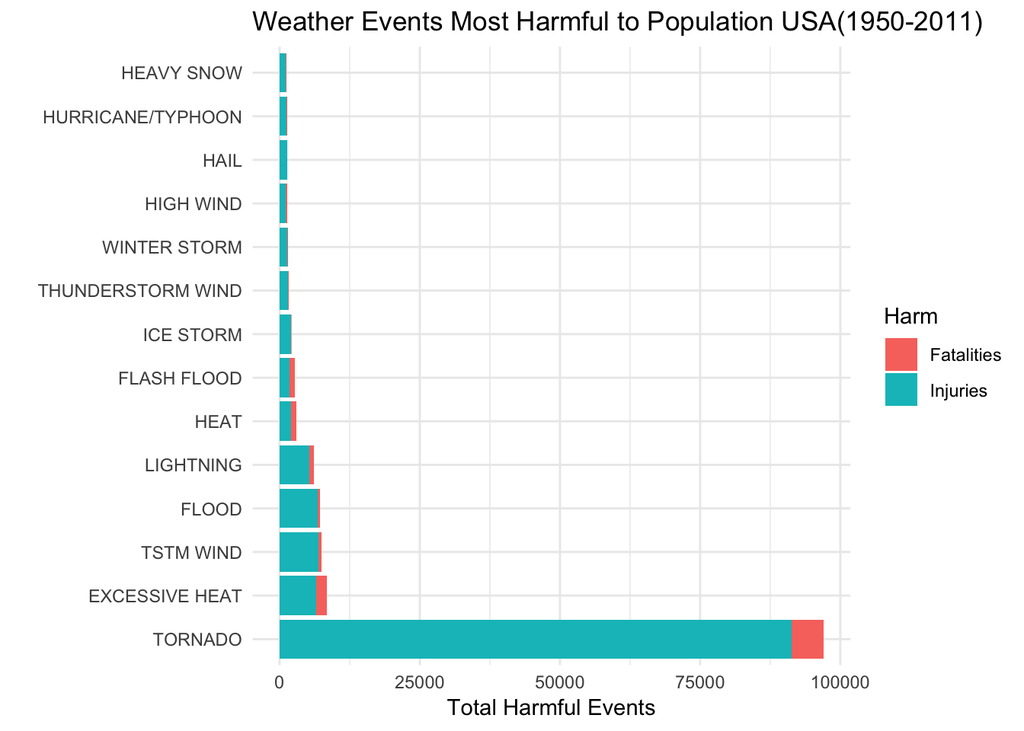

```r
ggplot(by_event)+
  aes(x=reorder(EVTYPE,-TOTAL),y= Amount, fill= Harm)+
  geom_bar(stat = "identity")+
  coord_flip()+
  labs(y="Total Harmful Events", x = "",title="Weather Events Most Harmful to Population USA(1950-2011)")+
  theme_minimal()
```

### Most Costly Weather Events ins USA(1950-2011)

The events with cost related damege over 2 billions are ploted. In terms of the cost the flood event is ranked number one follow by Hurricane and Tornados. Once again ggplot is used to plot the results.

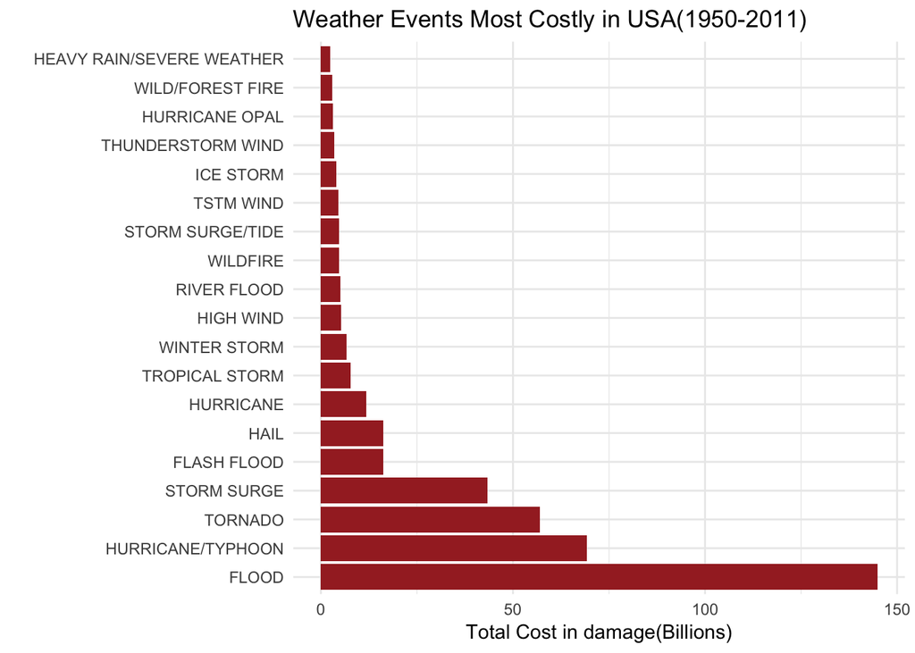

```r
ggplot(filter(compilation,compilation$Total > 2))+
  aes(x=reorder(EVTYPE,-Total),y= Total)+
  geom_bar(stat = "identity",fill="brown")+
  coord_flip()+
  labs(y="Total Cost in damage(Billions)", x = "",title="Weather Events Most Costly in USA(1950-2011)")+
  theme_minimal()
```